# Compare Salmon Network Stats Across Ports

Preparation for network analysis for CCIEA SSC-ES meeting September 2022

J. Samhouri

Written Sep 14, 2022. Last Run 2022-09-15

# Description

This document graphs network metrics for salmon alongside revenue by port groups.

# Setup

This script requires the following packages.

Select your directories.

What are the names of the `.csv` files with the network statistics that you want to compare? Would not suggest listing more than 4. Files should all be in the input directory (`indir`) specified above.

```r
filenames <- c("VesselLevelNodeStats_2004_2020_21pcgroups_totalrev5000_indivrev500_connectivity_rmCrab_10pContribution.csv")

networkstats_filename <- "VesselLevelNetworkStats_2004_2020_21pcgroups_totalrev5000_indivrev500_connectivity_rmCrab_10pContribution.csv"

port_filename <- 'iopac_conversion_table.csv'

tix_filenames <- c(
  'fish_tickets_crab2015_processed_for_networks.csv',
  'fish_tickets_crab2016_processed_for_networks.csv',
  'fish_tickets_crab2017_processed_for_networks.csv',
  'fish_tickets_crab2018_processed_for_networks.csv',
  'fish_tickets_crab2019_processed_for_networks.csv',
  'fish_tickets_crab2020_processed_for_networks.csv'
  )
```

Provide descriptive names to differentiate the datasets drawn from the files listed above.

Specify which network metrics and fish tix info to retain from the full data set.

```r
node_metrics <- c('node_strength','eigen')

network_metrics <- c('ed') # ,'ed_weighted'

landings_metrics <- c('adjrev', 'pounds')
```

Specify which fisheries to retain from the full data set.

```r
myfisheries <- c('Salmon')
my_spgroup <- c(30)
```

Specify IOPAC port groups to retain from the full data set, and read them in. Focus on all except ‘Unknown Ports’

# Read in Data

Network metrics from different datasets.

```r
for(i in seq(1,length(filenames))){
  tmpdat <- read.csv(here::here(indir, filenames[i])) %>%
    dplyr::select(pcgroup, year, metier.cm, all_of(node_metrics)) %>%
    filter(pcgroup %in% all_iopac) %>%
    filter(metier.cm %in% myfisheries) %>%
    mutate(dataset=dataset_names[i])
  if(i==1){
    dat <- tmpdat
  } else{ dat <- bind_rows(dat,tmpdat)}
}

dat <- dat %>% distinct() # remove duplicated WA Coast entries
head(dat)
```

|  | pcgroup | year | metier.cm | node_strength | eigen | dataset |
| --- | --- | --- | --- | --- | --- | --- |
| 1 | Puget Sound | 2004 | Salmon | 0.08796892 | 0.03859436 | NodeStats |
| 2 | North WA Coast | 2004 | Salmon | 0.11580228 | 0.15441887 | NodeStats |
| 3 | WA Coast | 2004 | Salmon | 0.09779177 | 0.12324317 | NodeStats |
| 4 | Other Coastal Washington | 2004 | Salmon | NaN | 1.00000000 | NodeStats |
| 5 | Astoria | 2004 | Salmon | 0.03404752 | 0.01468680 | NodeStats |
| 6 | Tillamook | 2004 | Salmon | 0.58455386 | 0.83365123 | NodeStats |

```r
for(i in seq(1,length(networkstats_filename))){
  tmpdat2 <- read.csv(here::here(indir, networkstats_filename[i])) %>%
    dplyr::select(pcgroup, y, all_of(network_metrics)) %>%
    #filter(pcgroup %in% myports) %>%
    #filter(metier.cm %in% myfisheries) %>%
    mutate(dataset=dataset_names2[i])
  if(i==1){
    dat2 <- tmpdat2
  } else{ dat2 <- bind_rows(dat2,tmpdat2)}
}

dat2 <- dat2 %>% distinct() # remove duplicated WA Coast entries
head(dat2)
```

|  | pcgroup | y | ed | dataset |
| --- | --- | --- | --- | --- |
| 1 | Puget Sound | 2004 | 0.3090909 | Network_Stats |
| 2 | North WA Coast | 2004 | 0.5238095 | Network_Stats |
| 3 | WA Coast | 2004 | 0.6785714 | Network_Stats |
| 4 | Other Coastal Washington | 2004 | NA | Network_Stats |
| 5 | Astoria | 2004 | 0.6388889 | Network_Stats |
| 6 | Tillamook | 2004 | 0.4761905 | Network_Stats |

Revenue and landings from different datasets.

```r
for(i in seq(1,length(tix_filenames))){
  tmpdat3 <- read.csv(paste0(indir3, tix_filenames[i])) %>%
    #dplyr::select(pcgroup, year, metier.cm, all_of(node_metrics)) %>%
    filter(IOPAC %in% all_iopac) %>%
    filter(SPGRPN2 %in% my_spgroup) %>%
    group_by(crab_year, IOPAC, SPGRPN2) %>%
    summarise(
      adjrev = sum(adj_revenue, na.rm=TRUE), # may want to remove na.rm
      pounds = sum(pounds, na.rm=TRUE), # may want to remove na.rm
      num_vessels = length(unique(drvid)),
      .groups = "drop"
    ) %>%
    mutate(
      metier.cm = "Salmon"
    )
    #mutate(dataset=dataset_names[i])
  if(i==1){
    dat3 <- tmpdat3
  } else{ dat3 <- bind_rows(dat3,tmpdat3)}
}

head(dat3)
```

| crab_year | IOPAC | SPGRPN2 | adjrev | pounds | num_vessels | metier.cm |
| --- | --- | --- | --- | --- | --- | --- |
| 2015 | Astoria | 30 | 190982.1 | 25445 | 66 | Salmon |
| 2015 | Bodega Bay | 30 | 102013.9 | 10736 | 39 | Salmon |
| 2015 | Brookings | 30 | 116877.4 | 14041 | 38 | Salmon |
| 2015 | Columbia River | 30 | 2725789.7 | 785594 | 169 | Salmon |
| 2015 | Coos Bay | 30 | 878240.1 | 113903 | 98 | Salmon |
| 2015 | Eureka | 30 | 42570.0 | 4806 | 13 | Salmon |

Check to make sure that all of the datasets were read in.

Pivot longer to graph multiple network metrics or summary stats at once.

Clean up metric names.

Make wide data frame for plotting and/or analysis.

Note that if there is only one node in a network, the Edge Density value is NA So we have arbitrarily set Edge Density to zero in the one port where this issue occurs (Columbia River).

# Graph Plot of Salmon Dependence Against Fishery Participation Network Edge Density

… at IOPAC ports for 2020-2021 fishing year. Network metrics (Edge Density, Importance) were derived from vessel-level networks summarized at the port level. Nodes (fisheries) are included in each network with a minimum total fisheries revenue cutoff for vessels of `$5,000` and a minimum revenue cutoff for individual fisheries of `$500`.

Make plot

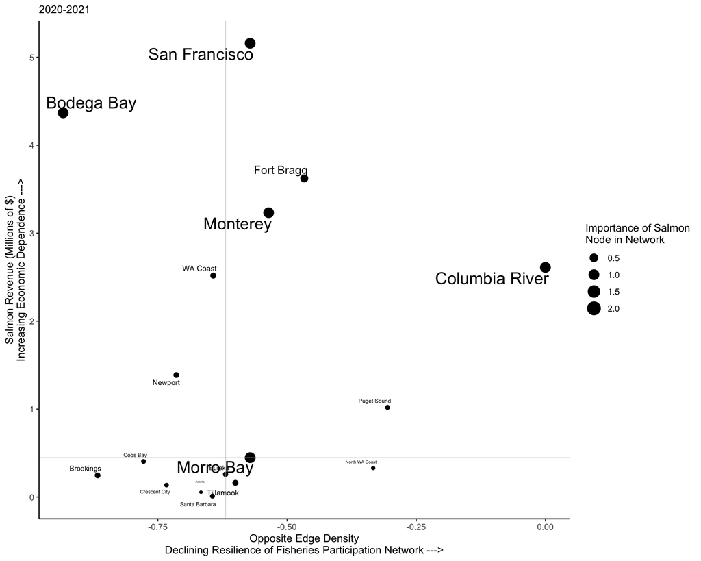

We define a port group vulnerable to declines in the salmon fishery as one that has high economic dependence on the salmon fishery, a fisheries participation network with relatively low connectivity among fisheries, and a salmon node within that fisheries participation network that is strongly connected to other fisheries. In this plot, larger points in the upper right quadrant indicate IOPAC port groups that are most vulnerable to declines in the salmon fishery (e.g., Columbia River, Fort Bragg, Monterey), while smaller points nearer to the origin indicate IOPAC port groups that are least vulnerable (e.g., Brookings, Coos Bay). This framework was inspired by Figure 4 in: Moore, S.K., Cline, M.R., Blair, K., Klinger, T., Varney, A. & Norman, K. (2019). An index of fisheries closures due to harmful algal blooms and a framework for identifying vulnerable fishing communities on the U.S. West Coast. Marine Policy, 103543.

The x-axis, Opposite Edge Density, is a statistic derived from the fisheries participation network for each IOPAC port group. Edge Density is calculated as the ratio of the number of edges present to the total possible edges in the network, and represents the extent to which nodes within a network are connected by vessels that participate in multiple fisheries. Higher Edge Densities correspond to greater flexibility in fishery participation among all vessels represented in the network. Note that Edge Density scales with network size (it is easier to achieve a high density in a low complexity network), so comparisons across networks of different sizes should be interpreted carefully. With that caveat in mind, declines in Edge Density imply a simplification of network structure, which can in turn reduce resilience to environmental or regulatory shocks (e.g., Fisher et al. 2021). Here we have multiplied Edge Density by negative one so that values farther to the right reflect simpler, less well-connected fisheries participation networks.

The y-axis, salmon revenue, reflects the aggregate ex-vessel value of salmon landed in each IOPAC port group.

Point size in this plot scales with Importance (also called eigenvector centrality), a statistic derived from the salmon node within each fisheries participation network for each IOPAC port group. A relatively large Importance value of the salmon node within a network signifies that it is well-connected to other well-connected fisheries. Larger points reflect salmon nodes that are more strongly connected to other fisheries, suggesting that impacts to the salmon node are more likely to cascade to other fisheries. Note that networks with more nodes tend to have nodes with higher Importance values. (Also see Figure T.5 of the 2022 ESR, and associated text).

Grey lines in this plot are for reference only, and indicate median values of the x- and y-axes.

### Save plots as pngs